# Baseball to Softball

```r
#in order to run this code, you will need to install these packages. You can do so by going to the install button, or by going to the console and typing, for example, install.packages("knitr")
suppressPackageStartupMessages(library(knitr)) #makes pdfs
suppressPackageStartupMessages(library(latex2exp))
suppressPackageStartupMessages(library(tidyverse)) #good library for data manipulation, includes dplyr and ggplot
suppressPackageStartupMessages(library(retrosheet))
suppressPackageStartupMessages(library(Lahman))

# you can read more about the tidyverse at: https://r4ds.had.co.nz/
knitr::opts_chunk$set(echo = TRUE)
```

Read in CSV

```r
retro_sheet_column_names <- c(
  "game_id", "visiting_team_df", "inning", "batting_team_df", "outs", "balls",
  "strikes", "pitch_sequence", "vis_score", "home_score", "batter",
  "batter_hand", "res_batter", "res_batter_hand", "pitcher", "pitcher_hand",
  "res_pitcher", "res_pitcher_hand", "catcher", "first_base", "second_base",
  "third_base", "shortstop", "left_field", "center_field", "right_field",
  "first_runner", "second_runner", "third_runner", "event_text",
  "leadoff_flag", "pinchhit_flag", "defensive_position", "lineup_position",
  "event_type", "batter_event_flag", "ab_flag", "hit_value", "SH_flag",
  "SF_flag", "outs_on_play", "double_play_flag", "triple_play_flag",
  "RBI_on_play", "wild_pitch_flag", "passed_ball_flag", "fielded_by",
  "batted_ball_type", "bunt_flag", "foul_flag", "hit_location", "num_errors",
  "1st_error_player", "1st_error_type", "2nd_error_player", "2nd_error_type",
  "3rd_error_player", "3rd_error_type", "batter_dest",
  "runner_on_1st_dest", "runner_on_2nd_dest", "runner_on_3rd_dest",
  "play_on_batter", "play_on_runner_on_1st", "play_on_runner_on_2nd",
  "play_on_runner_on_3rd", "SB_for_runner_on_1st_flag",
  "SB_for_runner_on_2nd_flag", "SB_for_runner_on_3rd_flag",
  "CS_for_runner_on_1st_flag", "CS_for_runner_on_2nd_flag",
  "CS_for_runner_on_3rd_flag", "PO_for_runner_on_1st_flag",
  "PO_for_runner_on_2nd_flag", "PO_for_runner_on_3rd_flag",
  "Responsible_pitcher_for_runner_on_1st",
  "Responsible_pitcher_for_runner_on_2nd",
  "Responsible_pitcher_for_runner_on_3rd", "New_Game_Flag",
  "End_Game_Flag", "Pinch_runner_on_1st", "Pinch_runner_on_2nd",
  "Pinch_runner_on_3rd", "Runner_removed_for_pinch_runner_on_1st",
  "Runner_removed_for_pinch_runner_on_2nd",
  "Runner_removed_for_pinch_runner_on_3rd",
  "Batter_removed_for_pinch_hitter",
  "Position_of_batter_removed_for_pinch_hitter",
  "Fielder_with_First_Putout", "Fielder_with_Second_Putout",
  "Fielder_with_Third_Putout", "Fielder_with_First_Assist",
  "Fielder_with_Second_Assist", "Fielder_with_Third_Assist",
  "Fielder_with_Fourth_Assist", "Fielder_with_Fifth_Assist", "event_num"
)
```

## Let’s load in the Data

```r
team_df = read.csv("/Users/bryanmongeserrano/Downloads/Baseball_Markov_Matrix-main/Giants/Giants_2015_2023.csv", header = FALSE )
colnames(team_df) <- retro_sheet_column_names
team_df <- team_df[-1,] #RBIND ADDITION
team_df$outs <- as.integer(team_df$outs)#RBIND ADDITION
team_df$event_type <- as.integer(team_df$event_type)#RBIND ADDITION

total_events = nrow(team_df)
```

```r
teamB_df = read.csv("/Users/bryanmongeserrano/Downloads/Baseball_Markov_Matrix-main/Yankees/Yankees_2015_2023.csv", header = FALSE )
colnames(teamB_df) <- retro_sheet_column_names
teamB_df <- teamB_df[-1,] #RBIND ADDITION
teamB_df$outs <- as.integer(teamB_df$outs)#RBIND ADDITION
teamB_df$event_type <- as.integer(teamB_df$event_type)#RBIND ADDITION

total_events = nrow(teamB_df)
```

## Let’s Add in Our Assumptions:

```r
# Remove All Double Plays and Triple Plays
team_df = team_df[team_df$outs_on_play < 2,]
# Only Have Walks, Single, Doubles, Triples, and Homeruns, General Outs, Strikeouts
team_df <- subset(
  team_df,
  team_df$event_type == 2 |
  team_df$event_type == 3 |
  team_df$event_type == 14|
  team_df$event_type == 20|
  team_df$event_type == 21|
  team_df$event_type == 22|
  team_df$event_type == 23
  )
```

```r
# Remove All Double Plays and Triple Plays
teamB_df = team_df[teamB_df$outs_on_play < 2,]
# Only Have Walks, Single, Doubles, Triples, and Homeruns, General Outs, Strikeouts
teamB_df <- subset(
  teamB_df,
  teamB_df$event_type == 2 |
  teamB_df$event_type == 3 |
  teamB_df$event_type == 14|
  teamB_df$event_type == 20|
  teamB_df$event_type == 21|
  teamB_df$event_type == 22|
  teamB_df$event_type == 23
  )
```

```r
# Calculate The Total Number of Homeruns
total_hrs = 0
for (i in 1:nrow(team_df)) {
  if (team_df$event_type[i] == 23) {
    total_hrs <- total_hrs + 1
  }
}
total_hrs
```

```
[1] 1182
```

```r
# Calculate The Total Number of Homeruns
total_hrs = 0
for (i in 1:nrow(teamB_df)) {
  if (teamB_df$event_type[i] == 23) {
    total_hrs <- total_hrs + 1
  }
}
total_hrs
```

```
[1] 1164
```

## Print Number of Total Events: This is basically going to be the denominator

```r
# Updated total events
total_events = nrow(team_df)
total_events
```

```
[1] 49022
```

```r
total_events = nrow(teamB_df)
total_events
```

```
[1] 48084
```

## Let’s Set Up the Baseball Matrix

```r
# Because we add row 25 for "3 outs" absorbing state
teamA_matrix<- matrix(0, nrow = 25, ncol = 25)
teamB_matrix<- matrix(0, nrow = 25, ncol = 25)
teamA_matrix
```

```
      [,1] [,2] [,3] [,4] [,5] [,6] [,7] [,8] [,9] [,10] [,11] [,12] [,13] [,14] [,15] [,16] [,17] [,18] [,19] [,20] [,21] [,22] [,23] [,24]
 [1,]    0    0    0    0    0    0    0    0    0     0     0     0     0     0     0     0     0     0     0     0     0     0     0     0
 [2,]    0    0    0    0    0    0    0    0    0     0     0     0     0     0     0     0     0     0     0     0     0     0     0     0
 [3,]    0    0    0    0    0    0    0    0    0     0     0     0     0     0     0     0     0     0     0     0     0     0     0     0
 [4,]    0    0    0    0    0    0    0    0    0     0     0     0     0     0     0     0     0     0     0     0     0     0     0     0
 [5,]    0    0    0    0    0    0    0    0    0     0     0     0     0     0     0     0     0     0     0     0     0     0     0     0
 [6,]    0    0    0    0    0    0    0    0    0     0     0     0     0     0     0     0     0     0     0     0     0     0     0     0
 [7,]    0    0    0    0    0    0    0    0    0     0     0     0     0     0     0     0     0     0     0     0     0     0     0     0
 [8,]    0    0    0    0    0    0    0    0    0     0     0     0     0     0     0     0     0     0     0     0     0     0     0     0
 [9,]    0    0    0    0    0    0    0    0    0     0     0     0     0     0     0     0     0     0     0     0     0     0     0     0
[10,]    0    0    0    0    0    0    0    0    0     0     0     0     0     0     0     0     0     0     0     0     0     0     0     0
[11,]    0    0    0    0    0    0    0    0    0     0     0     0     0     0     0     0     0     0     0     0     0     0     0     0
[12,]    0    0    0    0    0    0    0    0    0     0     0     0     0     0     0     0     0     0     0     0     0     0     0     0
[13,]    0    0    0    0    0    0    0    0    0     0     0     0     0     0     0     0     0     0     0     0     0     0     0     0
[14,]    0    0    0    0    0    0    0    0    0     0     0     0     0     0     0     0     0     0     0     0     0     0     0     0
```

[output cut: 37 more lines]

## Helper Functions to Populate Baseball Matrix

This function will return a list that will contain the row and col index values so we can index into the baseball matrix (24 x 24) (with an additional row and column for the absorbing state) when iterating through the dataframe on the next cell. This function will handle all the events where there are no runners on base

```r
no_runners_on <- function(outs, event, outs_on_play) {
  # Event For Homerun
  from_index = 1 + (8 * outs)
  # Event For Single
  if (event == 20 || event == 14) {
    return (c(from_index, from_index + 1))
  }
  # Event For Double
  if (event == 21) {
    return (c(from_index, from_index + 2))
  }
  # Event For Triple
  if (event == 22) {
    return (c(from_index, from_index + 3))
  }
  # Event For Homerun
  if (event == 23) {
    return (c(from_index, from_index))
  }
  # 0 Outs -> 1 Out
  if (event == 2 || event == 3 && outs == 0 && outs_on_play == 1) {
    return(c(from_index, from_index + 8))
  }
  # 1 Out -> 2 Outs
  if (event == 2 || event == 3 && outs == 1 && outs_on_play == 1) {
    return(c(from_index, from_index + 8))
  }
    # Will Handle 2 Outs -> 3 Outs Later  {WOULD  RECCOMEND PUTTING THE 2 OUTS -> 3 OUTS STATEMENT ABOVE}
  # 2 Outs -> 3 Outs
  if ((event == 2 || event == 3) && outs == 2 && outs_on_play == 1) {
    return(c(17, 25))
  }

  #Edge Case -> There are Outs_on_Play = 0 Just Return [0, 0]
  return(c(0, 0))
}
```

This function will return a list that will contain the row and col index values so we can index into the baseball matrix (24 x 24) when iterating through the dataframe on the next cell. This function will handle all the events where there are runners on first base

```r
runner_on_first <- function(outs, event, outs_on_play) {
  # Event For Homerun
  from_index = 2 + (8 * outs)
  # Event For Single
  if (event == 20 || event == 14) {
    return (c(from_index, from_index + 3))
  }
  # Event For Double
  if (event == 21) {
    return (c(from_index, from_index + 5))
  }
  # Event For Triple
  if (event == 22) {
    return (c(from_index, from_index + 2))
  }
  # Event For Homerun
  if (event == 23) {
    return (c(from_index, from_index - 1))
  }
  # 0 Outs -> 1 Out
  if (event == 2 || event == 3 && outs == 0 && outs_on_play == 1) {
    return(c(from_index, from_index + 8))
  }
  # 1 Out -> 2 Outs
  if (event == 2 || event == 3 && outs == 1 && outs_on_play == 1) {
    return(c(from_index, from_index + 8))
  }
  # Will Handle 2 Outs -> 3 Outs Later  {WOULD  RECCOMEND PUTTING THE 2 OUTS -> 3 OUTS STATEMENT ABOVE}
  # 2 Outs -> 3 Outs
  if ((event == 2 || event == 3) && outs == 2 && outs_on_play == 1) {
    return(c(18, 25))
  }
  #Edge Case -> There are Outs_on_Play = 0 Just Return [0, 0]
  return(c(0, 0))
}
```

This function will return a list that will contain the row and col index values so we can index into the baseball matrix (24 x 24) when iterating through the dataframe on the next cell.

This function will handle all the events where there are runners on second base

```r
runner_on_second <- function(outs, event, outs_on_play) {
  from_index = 3 + (8 * outs)
  # Event For Single
  if (event == 20 || event == 14) {
    return (c(from_index, from_index + 2))
  }
  # Event For Double
  if (event == 21) {
    return (c(from_index, from_index))
  }
  # Event For Triple
  if (event == 22) {
    return (c(from_index, from_index + 1))
  }
  # Event For Homerun
  if (event == 23) {
    return (c(from_index, from_index - 2))
  }
  # 0 Outs -> 1 Out
  if (event == 2 || event == 3 && outs == 0 && outs_on_play == 1) {
    return(c(from_index, from_index + 8))
  }
  # 1 Out -> 2 Outs
  if (event == 2 || event == 3 && outs == 1 && outs_on_play == 1) {
    return(c(from_index, from_index + 8))
  }
  # Will Handle 2 Outs -> 3 Outs Later  {WOULD  RECCOMEND PUTTING THE 2 OUTS -> 3 OUTS STATEMENT ABOVE}
  # 2 Outs -> 3 Outs
  if ((event == 2 || event == 3) && outs == 2 && outs_on_play == 1) {
    return(c(19, 25))
  }
  #Edge Case -> There are Outs_on_Play = 0 Just Return [0, 0]
  return(c(0, 0))
}
```

This function will return a list that will contain the row and col index values so we can index into the baseball matrix (24 x 24) when iterating through the dataframe on the next cell. This function will handle all the events where there are runners on third base

```r
runner_on_third <- function(outs, event, outs_on_play) {
  from_index = 4 + (8 * outs)
  # Event For a Walk
  if (event == 14) {
    return (c(from_index, from_index + 2))
  }
  # Event For a Single
  if (event == 20) {
    return (c(from_index, from_index - 2))
  }

  # Event For Double
  if (event == 21) {
    return (c(from_index, from_index - 1))
  }
  # Event For Triple
  if (event == 22) {
    return (c(from_index, from_index))
  }
  # Event For Homerun
  if (event == 23) {
    return (c(from_index, from_index - 3))
  }
  # 0 Outs -> 1 Out
  if (event == 2 || event == 3 && outs == 0 && outs_on_play == 1) {
    return(c(from_index, from_index + 8))
  }
  # 1 Out -> 2 Outs
  if (event == 2 || event == 3 && outs == 1 && outs_on_play == 1) {
    return(c(from_index, from_index + 8))
  }
  # Will Handle 2 Outs -> 3 Outs Later  {WOULD  RECCOMEND PUTTING THE 2 OUTS -> 3 OUTS STATEMENT ABOVE}
  # 2 Outs -> 3 Outs
  if ((event == 2 || event == 3) && outs == 2 && outs_on_play == 1) {
    return(c(20, 25))
  }
  #Edge Case -> There are Outs_on_Play = 0 Just Return [0, 0]
  return(c(0, 0))
}
```

This function will return a list that will contain the row and col index values so we can index into the baseball matrix (24 x 24) when iterating through the dataframe on the next cell.

This function will handle all the events where there are runners on first and second base

```r
runner_on_first_second <- function(outs, event, outs_on_play) {
  # Event For Homerun
  from_index = 5 + (8 * outs)
  # Event For Single
  if (event == 20 || event == 14) {
    return (c(from_index, from_index + 3))
  }
  # Event For Double
  if (event == 21) {
    return (c(from_index, from_index + 2))
  }
  # Event For Triple
  if (event == 22) {
    return (c(from_index, from_index - 1))
  }
  # Event For Homerun
  if (event == 23) {
    return (c(from_index, from_index - 4))
  }
  # I RECCOMEND IT HERE!
  # 0 Outs -> 1 Out
  if ((event == 2 || event == 3) && outs == 0 && outs_on_play == 1) {
    return(c(from_index, from_index + 8))
  }
  # 1 Outs -> 2 Outs
  if ((event == 2 || event == 3) && outs == 1 && outs_on_play == 1) {
    return(c(from_index, from_index + 8))
  }

  # Will Handle 2 Outs -> 3 Outs Later  {WOULD  RECCOMEND PUTTING THE 2 OUTS -> 3 OUTS STATEMENT ABOVE}
  # 2 Outs -> 3 Outs
  if ((event == 2 || event == 3) && outs == 2 && outs_on_play == 1) {
    return(c(21, 25))
  }
  #Edge Case -> There are Outs_on_Play = 0 Just Return [0, 0]
  return(c(0, 0))
}
```

This function will return a list that will contain the row and col index values so we can index into the baseball matrix (24 x 24) when iterating through the dataframe on the next cell.

This function will handle all the events where there are runners on first and third base

```r
runner_on_first_third <- function(outs, event, outs_on_play) {
  # Event For Homerun
  from_index = 6 + (8 * outs)
  # Event For Walk
  if (event == 14) {
    return (c(from_index, from_index + 2))
  }
  # Event For Single
  if (event == 20) {
    return (c(from_index, from_index - 1))
  }
  # Event For Double
  if (event == 21) {
    return (c(from_index, from_index + 1))
  }
  # Event For Triple
  if (event == 22) {
    return (c(from_index, from_index - 2))
  }
  # Event For Homerun
  if (event == 23) {
    return (c(from_index, from_index - 5))
  }
  # 0 Outs -> 1 Out
  if ((event == 2 || event == 3) && outs == 0 && outs_on_play == 1) {
    return(c(from_index, from_index + 8))
  }
  # 1 Out -> 2 Outs
  if ((event == 2 || event == 3) && outs == 1 && outs_on_play == 1) {
    return(c(from_index, from_index + 8))
  }

  # Will Handle 2 Outs -> 3 Outs Later
  if ((event == 2 || event == 3) && outs == 2 && outs_on_play == 1) {
    return(c(22, 25))
  }

  #Edge Case -> There are Outs_on_Play = 0 Just Return [0, 0]
  return(c(0, 0))
}
```

This function will return a list that will contain the row and col index values so we can index into the baseball matrix (24 x 24) when iterating through the dataframe on the next cell.

This function will handle all the events where there are runners on second and third base

```r
runner_on_second_third <- function(outs, event, outs_on_play) {
  from_index = 7 + (8 * outs)
  # Event For Single or Walk
  if (event == 20 || event == 14) {
    return (c(from_index, from_index - 1))
  }
  # Event For Double
  if (event == 21) {
    return (c(from_index, from_index - 4))
  }
  # Event For Triple
  if (event == 22) {
    return (c(from_index, from_index - 3))
  }
  # Event For Homerun
  if (event == 23) {
    return (c(from_index, from_index - 6))
  }
  # 0 Outs -> 1 Out
  if ((event == 2 || event == 3) && outs == 0 && outs_on_play == 1) {
    return(c(from_index, from_index + 8))
  }
  # 1 Out -> 2 Outs
  if ((event == 2 || event == 3) && outs == 1 && outs_on_play == 1) {
    return(c(from_index, from_index + 8))
  }

  # Will Handle 2 Outs -> 3 Outs Later
  if ((event == 2 || event == 3) && outs == 2 && outs_on_play == 1) {
    return(c(23, 25))
  }

  #Edge Case -> There are Outs_on_Play = 0 Just Return [0, 0]
  return(c(0, 0))
}
```

This function will return a list that will contain the row and col index values so we can index into the baseball matrix (24 x 24) when iterating through the dataframe on the next cell. This function will handle all the events where there are runners on first, second, and third base

```r
runner_on_first_second_third <- function(outs, event, outs_on_play) {
  # Event For Homerun
  from_index = 8 + (8 * outs)
  # Event For Single
  if (event == 20 || event == 14) {
    return (c(from_index, from_index))
  }
  # Event For Double
  if (event == 21) {
    return (c(from_index, from_index - 1))
  }
  # Event For Triple
  if (event == 22) {
    return (c(from_index, from_index - 4))
  }
  # Event For Homerun
  if (event == 23) {
    return (c(from_index, from_index - 7))
  }
  # 0 Outs -> 1 Out
  if ((event == 2 || event == 3) && outs == 0 && outs_on_play == 1) {
    return(c(from_index, from_index + 8))
  }
  # 1 Out -> 2 Outs
  if ((event == 2 || event == 3) && outs == 1 && outs_on_play == 1) {
    return(c(from_index, from_index + 8))
  }
  # 2 Outs -> 3 Outs Later
  if ((event == 2 || event == 3) && outs == 2 && outs_on_play == 1) {
    return(c(24, 25))
  }
  #Edge Case -> There are Outs_on_Play = 0 Just Return [0, 0]
  return(c(0, 0))
}
```

## Populate Baseball Matrix

```r
for (i in 1:nrow(team_df)) {
  # No Runners on Base
  if (team_df$first_runner[i] == '' &&
      team_df$second_runner[i] == '' &&
      team_df$third_runner[i] == '') {
    row_col = no_runners_on(team_df$outs[i],
                            team_df$event_type[i],
                            team_df$outs_on_play[i])
    row = row_col[1]
    col = row_col[2]
    if (row != 0 && col != 0 && row <= nrow(teamA_matrix) && col <= ncol(teamA_matrix)) {
      teamA_matrix[row, col] <- teamA_matrix[row, col] + 1
    }
  }

  # Runner on First Base
  if (team_df$first_runner[i] != '' &&
      team_df$second_runner[i] == '' &&
      team_df$third_runner[i] == '') {
    row_col = runner_on_first(team_df$outs[i],
                              team_df$event_type[i],
                              team_df$outs_on_play[i])
    row = row_col[1]
    col = row_col[2]
    if (row != 0 && col != 0 && row <= nrow(teamA_matrix) && col <= ncol(teamA_matrix)) {
      teamA_matrix[row, col] <- teamA_matrix[row, col] + 1
    }
  }

  # Runner on Second Base
  if (team_df$first_runner[i] == '' &&
      team_df$second_runner[i] != '' &&
      team_df$third_runner[i] == '') {
    row_col = runner_on_second(team_df$outs[i],
                               team_df$event_type[i],
                               team_df$outs_on_play[i])
    row = row_col[1]
    col = row_col[2]
    if (row != 0 && col != 0 && row <= nrow(teamA_matrix) && col <= ncol(teamA_matrix)) {
      teamA_matrix[row, col] <- teamA_matrix[row, col] + 1
    }
  }

  # Runner on Third
  if (team_df$first_runner[i] == '' &&
      team_df$second_runner[i] == '' &&
      team_df$third_runner[i] != '') {
    row_col = runner_on_third(team_df$outs[i],
                              team_df$event_type[i],
                              team_df$outs_on_play[i])
    row = row_col[1]
    col = row_col[2]
    if (row != 0 && col != 0 && row <= nrow(teamA_matrix) && col <= ncol(teamA_matrix)) {
      teamA_matrix[row, col] <- teamA_matrix[row, col] + 1
    }
  }

  # Runner on First & Second
  if (team_df$first_runner[i] != '' &&
      team_df$second_runner[i] != '' &&
      team_df$third_runner[i] == '') {
    row_col = runner_on_first_second(team_df$outs[i],
                                     team_df$event_type[i],
                                     team_df$outs_on_play[i])
    row = row_col[1]
    col = row_col[2]
    if (row != 0 && col != 0 && row <= nrow(teamA_matrix) && col <= ncol(teamA_matrix)) {
      teamA_matrix[row, col] <- teamA_matrix[row, col] + 1
    }
  }

  # Runner on First & Third
  if (team_df$first_runner[i] != '' &&
      team_df$second_runner[i] == '' &&
      team_df$third_runner[i] != '') {
    row_col = runner_on_first_third(team_df$outs[i],
                                    team_df$event_type[i],
                                    team_df$outs_on_play[i])
    row = row_col[1]
    col = row_col[2]
    if (row != 0 && col != 0 && row <= nrow(teamA_matrix) && col <= ncol(teamA_matrix)) {
      teamA_matrix[row, col] <- teamA_matrix[row, col] + 1
    }
  }

  # Runner on Second & Third
  if (team_df$first_runner[i] == '' &&
      team_df$second_runner[i] != '' &&
      team_df$third_runner[i] != '') {
    row_col = runner_on_second_third(team_df$outs[i],
                                     team_df$event_type[i],
                                     team_df$outs_on_play[i])
    row = row_col[1]
    col = row_col[2]
    if (row != 0 && col != 0 && row <= nrow(teamA_matrix) && col <= ncol(teamA_matrix)) {
      teamA_matrix[row, col] <- teamA_matrix[row, col] + 1
    }
  }

  # Runner on First, Second, & Third
  if (team_df$first_runner[i] != '' &&
      team_df$second_runner[i] != '' &&
      team_df$third_runner[i] != '') {
    row_col = runner_on_first_second_third(team_df$outs[i],
                                           team_df$event_type[i],
                                           team_df$outs_on_play[i])
    row = row_col[1]
    col = row_col[2]
    if (row != 0 && col != 0 && row <= nrow(teamA_matrix) && col <= ncol(teamA_matrix)) {
      teamA_matrix[row, col] <- teamA_matrix[row, col] + 1
    }
  }
}
```

```r
for (i in 1:nrow(teamB_df)) {
  # No Runners on Base
  if (teamB_df$first_runner[i] == '' &&
      teamB_df$second_runner[i] == '' &&
      teamB_df$third_runner[i] == '') {
    row_col = no_runners_on(teamB_df$outs[i],
                            teamB_df$event_type[i],
                            teamB_df$outs_on_play[i])
    row = row_col[1]
    col = row_col[2]
    if (row != 0 && col != 0 && row <= nrow(teamB_matrix) && col <= ncol(teamB_matrix)) {
      teamB_matrix[row, col] <- teamB_matrix[row, col] + 1
    }
  }

  # Runner on First Base
  if (teamB_df$first_runner[i] != '' &&
      teamB_df$second_runner[i] == '' &&
      teamB_df$third_runner[i] == '') {
    row_col = runner_on_first(teamB_df$outs[i],
                              teamB_df$event_type[i],
                              teamB_df$outs_on_play[i])
    row = row_col[1]
    col = row_col[2]
    if (row != 0 && col != 0 && row <= nrow(teamB_matrix) && col <= ncol(teamB_matrix)) {
      teamB_matrix[row, col] <- teamB_matrix[row, col] + 1
    }
  }

  # Runner on Second Base
  if (teamB_df$first_runner[i] == '' &&
      teamB_df$second_runner[i] != '' &&
      teamB_df$third_runner[i] == '') {
    row_col = runner_on_second(teamB_df$outs[i],
                               teamB_df$event_type[i],
                               teamB_df$outs_on_play[i])
    row = row_col[1]
    col = row_col[2]
    if (row != 0 && col != 0 && row <= nrow(teamB_matrix) && col <= ncol(teamB_matrix)) {
      teamB_matrix[row, col] <- teamB_matrix[row, col] + 1
    }
  }

  # Runner on Third
  if (teamB_df$first_runner[i] == '' &&
      teamB_df$second_runner[i] == '' &&
      teamB_df$third_runner[i] != '') {
    row_col = runner_on_third(teamB_df$outs[i],
                              teamB_df$event_type[i],
                              teamB_df$outs_on_play[i])
    row = row_col[1]
    col = row_col[2]
    if (row != 0 && col != 0 && row <= nrow(teamB_matrix) && col <= ncol(teamB_matrix)) {
      teamB_matrix[row, col] <- teamB_matrix[row, col] + 1
    }
  }

  # Runner on First & Second
  if (teamB_df$first_runner[i] != '' &&
      teamB_df$second_runner[i] != '' &&
      teamB_df$third_runner[i] == '') {
    row_col = runner_on_first_second(teamB_df$outs[i],
                                     teamB_df$event_type[i],
                                     teamB_df$outs_on_play[i])
    row = row_col[1]
    col = row_col[2]
    if (row != 0 && col != 0 && row <= nrow(teamB_matrix) && col <= ncol(teamB_matrix)) {
      teamB_matrix[row, col] <- teamB_matrix[row, col] + 1
    }
  }

  # Runner on First & Third
  if (teamB_df$first_runner[i] != '' &&
      teamB_df$second_runner[i] == '' &&
      teamB_df$third_runner[i] != '') {
    row_col = runner_on_first_third(teamB_df$outs[i],
                                    teamB_df$event_type[i],
                                    teamB_df$outs_on_play[i])
    row = row_col[1]
    col = row_col[2]
    if (row != 0 && col != 0 && row <= nrow(teamB_matrix) && col <= ncol(teamB_matrix)) {
      teamB_matrix[row, col] <- teamB_matrix[row, col] + 1
    }
  }

  # Runner on Second & Third
  if (teamB_df$first_runner[i] == '' &&
      teamB_df$second_runner[i] != '' &&
      teamB_df$third_runner[i] != '') {
    row_col = runner_on_second_third(teamB_df$outs[i],
                                     teamB_df$event_type[i],
                                     teamB_df$outs_on_play[i])
    row = row_col[1]
    col = row_col[2]
    if (row != 0 && col != 0 && row <= nrow(teamB_matrix) && col <= ncol(teamB_matrix)) {
      teamB_matrix[row, col] <- teamB_matrix[row, col] + 1
    }
  }

  # Runner on First, Second, & Third
  if (teamB_df$first_runner[i] != '' &&
      teamB_df$second_runner[i] != '' &&
      teamB_df$third_runner[i] != '') {
    row_col = runner_on_first_second_third(teamB_df$outs[i],
                                           teamB_df$event_type[i],
                                           teamB_df$outs_on_play[i])
    row = row_col[1]
    col = row_col[2]
    if (row != 0 && col != 0 && row <= nrow(teamB_matrix) && col <= ncol(teamB_matrix)) {
      teamB_matrix[row, col] <- teamB_matrix[row, col] + 1
    }
  }
}
```

## Display Matrix with Event Counts

```r
teamA_matrix
```

```
      [,1] [,2] [,3] [,4] [,5] [,6] [,7] [,8] [,9] [,10] [,11] [,12] [,13] [,14] [,15] [,16] [,17] [,18] [,19] [,20] [,21] [,22] [,23] [,24]
 [1,]  323 2791  555   98    0    0    0    0 8633     0     0     0     0     0     0     0     0     0     0     0     0     0     0     0
 [2,]   77    0    0   18  612    0  141    0    0  1597     0     0     0     0     0     0     0     0     0     0     0     0     0     0
 [3,]   20    0   39    1  199    0    0    0    0     0   573     0     0     0     0     0     0     0     0     0     0     0     0     0
 [4,]    3   39    6    1    0   11    0    0    0     0     0   111     0     0     0     0     0     0     0     0     0     0     0     0
 [5,]   12    0    0    6    0    0   34  162    0     0     0     0   402     0     0     0     0     0     0     0     0     0     0     0
 [6,]    5    0    0    5   33    0    9   12    0     0     0     0     0   126     0     0     0     0     0     0     0     0     0     0
 [7,]    2    0    8    1    0   43    0    0    0     0     0     0     0     0   118     0     0     0     0     0     0     0     0     0
 [8,]    2    0    0    1    0    0    9   42    0     0     0     0     0     0     0   109     0     0     0     0     0     0     0     0
 [9,]    0    0    0    0    0    0    0    0  200  2012   394    48     0     0     0     0  6328     0     0     0     0     0     0     0
[10,]    0    0    0    0    0    0    0    0   82     0     0    16   766     0   176     0     0  1893     0     0     0     0     0     0
[11,]    0    0    0    0    0    0    0    0   37     0    60     7   366     0     0     0     0     0   880     0     0     0     0     0
[12,]    0    0    0    0    0    0    0    0   10    79    26     4     0    49     0     0     0     0     0   295     0     0     0     0
[13,]    0    0    0    0    0    0    0    0   27     0     0     4     0     0    39   279     0     0     0     0   684     0     0     0
[14,]    0    0    0    0    0    0    0    0   15     0     0     6    97     0    21    29     0     0     0     0     0   281     0     0
```

[output cut: 37 more lines]

```r
teamB_matrix
```

```
      [,1] [,2] [,3] [,4] [,5] [,6] [,7] [,8] [,9] [,10] [,11] [,12] [,13] [,14] [,15] [,16] [,17] [,18] [,19] [,20] [,21] [,22] [,23] [,24]
 [1,]  320 2746  547   94    0    0    0    0 8467     0     0     0     0     0     0     0     0     0     0     0     0     0     0     0
 [2,]   77    0    0   18  599    0  138    0    0  1568     0     0     0     0     0     0     0     0     0     0     0     0     0     0
 [3,]   20    0   39    1  194    0    0    0    0     0   564     0     0     0     0     0     0     0     0     0     0     0     0     0
 [4,]    3   36    6    1    0   11    0    0    0     0     0   109     0     0     0     0     0     0     0     0     0     0     0     0
 [5,]   12    0    0    5    0    0   33  157    0     0     0     0   391     0     0     0     0     0     0     0     0     0     0     0
 [6,]    5    0    0    5   32    0    9   12    0     0     0     0     0   122     0     0     0     0     0     0     0     0     0     0
 [7,]    2    0    8    1    0   43    0    0    0     0     0     0     0     0   117     0     0     0     0     0     0     0     0     0
 [8,]    2    0    0    1    0    0    9   42    0     0     0     0     0     0     0   109     0     0     0     0     0     0     0     0
 [9,]    0    0    0    0    0    0    0    0  192  1982   386    48     0     0     0     0  6197     0     0     0     0     0     0     0
[10,]    0    0    0    0    0    0    0    0   81     0     0    16   747     0   171     0     0  1858     0     0     0     0     0     0
[11,]    0    0    0    0    0    0    0    0   37     0    58     7   359     0     0     0     0     0   866     0     0     0     0     0
[12,]    0    0    0    0    0    0    0    0   10    77    26     4     0    49     0     0     0     0     0   292     0     0     0     0
[13,]    0    0    0    0    0    0    0    0   26     0     0     4     0     0    37   271     0     0     0     0   676     0     0     0
[14,]    0    0    0    0    0    0    0    0   13     0     0     6    97     0    21    29     0     0     0     0     0   277     0     0
```

[output cut: 37 more lines]

## Obtain Probabilites

```r
sum_row_1 <- rowSums(teamA_matrix[1, , drop = FALSE])
```

## Display Baseball Matrix With Probabilities

```r
# Convert to probabilities:
final_teamA_matrix <- teamA_matrix
for (i in 1:24) {
  row_sum <- sum(final_teamA_matrix[i, ])
  if (row_sum > 0) {
    final_teamA_matrix[i, ] <- final_teamA_matrix[i, ] / row_sum
  }
}
# Absorbing
final_teamA_matrix[25, 25] <- 1
final_teamA_matrix
```

```
            [,1]      [,2]       [,3]        [,4]      [,5]       [,6]       [,7]       [,8]       [,9]     [,10]      [,11]       [,12]
 [1,] 0.02604839 0.2250806 0.04475806 0.007903226 0.0000000 0.00000000 0.00000000 0.00000000 0.69620968 0.0000000 0.00000000 0.000000000
 [2,] 0.03149284 0.0000000 0.00000000 0.007361963 0.2503067 0.00000000 0.05766871 0.00000000 0.00000000 0.6531697 0.00000000 0.000000000
 [3,] 0.02403846 0.0000000 0.04687500 0.001201923 0.2391827 0.00000000 0.00000000 0.00000000 0.00000000 0.0000000 0.68870192 0.000000000
 [4,] 0.01754386 0.2280702 0.03508772 0.005847953 0.0000000 0.06432749 0.00000000 0.00000000 0.00000000 0.0000000 0.00000000 0.649122807
 [5,] 0.01948052 0.0000000 0.00000000 0.009740260 0.0000000 0.00000000 0.05519481 0.26298701 0.00000000 0.0000000 0.00000000 0.000000000
 [6,] 0.02631579 0.0000000 0.00000000 0.026315789 0.1736842 0.00000000 0.04736842 0.06315789 0.00000000 0.0000000 0.00000000 0.000000000
 [7,] 0.01162791 0.0000000 0.04651163 0.005813953 0.0000000 0.25000000 0.00000000 0.00000000 0.00000000 0.0000000 0.00000000 0.000000000
 [8,] 0.01226994 0.0000000 0.00000000 0.006134969 0.0000000 0.00000000 0.05521472 0.25766871 0.00000000 0.0000000 0.00000000 0.000000000
 [9,] 0.00000000 0.0000000 0.00000000 0.000000000 0.0000000 0.00000000 0.00000000 0.00000000 0.02226676 0.2240036 0.04386551 0.005344021
[10,] 0.00000000 0.0000000 0.00000000 0.000000000 0.0000000 0.00000000 0.00000000 0.00000000 0.02795772 0.0000000 0.00000000 0.005455165
[11,] 0.00000000 0.0000000 0.00000000 0.000000000 0.0000000 0.00000000 0.00000000 0.00000000 0.02740741 0.0000000 0.04444444 0.005185185
[12,] 0.00000000 0.0000000 0.00000000 0.000000000 0.0000000 0.00000000 0.00000000 0.00000000 0.02159827 0.1706263 0.05615551 0.008639309
[13,] 0.00000000 0.0000000 0.00000000 0.000000000 0.0000000 0.00000000 0.00000000 0.00000000 0.02613746 0.0000000 0.00000000 0.003872217
[14,] 0.00000000 0.0000000 0.00000000 0.000000000 0.0000000 0.00000000 0.00000000 0.00000000 0.03340757 0.0000000 0.00000000 0.013363029
```

[output cut: 63 more lines]

```r
# Convert to probabilities:
final_teamB_matrix <- teamB_matrix
for (i in 1:24) {
  row_sum <- sum(final_teamB_matrix[i, ])
  if (row_sum > 0) {
    final_teamB_matrix[i, ] <- final_teamB_matrix[i, ] / row_sum
  }
}

# Absorbing
final_teamB_matrix[25, 25] <- 1
final_teamB_matrix
```

```
            [,1]      [,2]       [,3]        [,4]      [,5]       [,6]       [,7]       [,8]       [,9]     [,10]      [,11]       [,12]
 [1,] 0.02628553 0.2255627 0.04493182 0.007721373 0.0000000 0.00000000 0.00000000 0.00000000 0.69549860 0.0000000 0.00000000 0.000000000
 [2,] 0.03208333 0.0000000 0.00000000 0.007500000 0.2495833 0.00000000 0.05750000 0.00000000 0.00000000 0.6533333 0.00000000 0.000000000
 [3,] 0.02444988 0.0000000 0.04767726 0.001222494 0.2371638 0.00000000 0.00000000 0.00000000 0.00000000 0.0000000 0.68948655 0.000000000
 [4,] 0.01807229 0.2168675 0.03614458 0.006024096 0.0000000 0.06626506 0.00000000 0.00000000 0.00000000 0.0000000 0.00000000 0.656626506
 [5,] 0.02006689 0.0000000 0.00000000 0.008361204 0.0000000 0.00000000 0.05518395 0.26254181 0.00000000 0.0000000 0.00000000 0.000000000
 [6,] 0.02702703 0.0000000 0.00000000 0.027027027 0.1729730 0.00000000 0.04864865 0.06486486 0.00000000 0.0000000 0.00000000 0.000000000
 [7,] 0.01169591 0.0000000 0.04678363 0.005847953 0.0000000 0.25146199 0.00000000 0.00000000 0.00000000 0.0000000 0.00000000 0.000000000
 [8,] 0.01226994 0.0000000 0.00000000 0.006134969 0.0000000 0.00000000 0.05521472 0.25766871 0.00000000 0.0000000 0.00000000 0.000000000
 [9,] 0.00000000 0.0000000 0.00000000 0.000000000 0.0000000 0.00000000 0.00000000 0.00000000 0.02180579 0.2250994 0.04383873 0.005451448
[10,] 0.00000000 0.0000000 0.00000000 0.000000000 0.0000000 0.00000000 0.00000000 0.00000000 0.02819353 0.0000000 0.00000000 0.005569092
[11,] 0.00000000 0.0000000 0.00000000 0.000000000 0.0000000 0.00000000 0.00000000 0.00000000 0.02788244 0.0000000 0.04370761 0.005275057
[12,] 0.00000000 0.0000000 0.00000000 0.000000000 0.0000000 0.00000000 0.00000000 0.00000000 0.02183406 0.1681223 0.05676856 0.008733624
[13,] 0.00000000 0.0000000 0.00000000 0.000000000 0.0000000 0.00000000 0.00000000 0.00000000 0.02564103 0.0000000 0.00000000 0.003944773
[14,] 0.00000000 0.0000000 0.00000000 0.000000000 0.0000000 0.00000000 0.00000000 0.00000000 0.02934537 0.0000000 0.00000000 0.013544018
```

[output cut: 63 more lines]

```r
# 1) Copy the final baseball-based matrix
softballA_matrix <- final_teamA_matrix

# 2) Define multipliers for your "softball environment"
hr_multiplier        <- 0.50  # reduce HR by 50%
single_multiplier    <- 1.20  # increase singles by 20%
double_multiplier    <- 1.10
triple_multiplier    <- 1.00
walk_multiplier      <- 1.00
strikeout_multiplier <- 1.05
out_multiplier       <- 1.00

# 3) Identify columns for each event (example only!)
COL_HR        <- 1  # user must confirm correct column index for HR
COL_SINGLE    <- 2
COL_DOUBLE    <- 3
COL_TRIPLE    <- 4
COL_WALK      <- 5
COL_STRIKEOUT <- 6
COL_OUT       <- 7

# 4) Scale rows 1..24, re-normalize
for (state_idx in 1:24) {
  # multiply columns
  softballA_matrix[state_idx, COL_HR]        <- softballA_matrix[state_idx, COL_HR]        * hr_multiplier
  softballA_matrix[state_idx, COL_SINGLE]    <- softballA_matrix[state_idx, COL_SINGLE]    * single_multiplier
  softballA_matrix[state_idx, COL_DOUBLE]    <- softballA_matrix[state_idx, COL_DOUBLE]    * double_multiplier
  softballA_matrix[state_idx, COL_TRIPLE]    <- softballA_matrix[state_idx, COL_TRIPLE]    * triple_multiplier
  softballA_matrix[state_idx, COL_WALK]      <- softballA_matrix[state_idx, COL_WALK]      * walk_multiplier
  softballA_matrix[state_idx, COL_STRIKEOUT] <- softballA_matrix[state_idx, COL_STRIKEOUT] * strikeout_multiplier
  softballA_matrix[state_idx, COL_OUT]       <- softballA_matrix[state_idx, COL_OUT]       * out_multiplier

  # re-normalize each row
  row_sum <- sum(softballA_matrix[state_idx, ])
  if (row_sum > 0) {
    softballA_matrix[state_idx, ] <- softballA_matrix[state_idx, ] / row_sum
  }
}

# Keep row 25 absorbing
softballA_matrix[25, 25] <- 1
```

```r
# 1) Copy the final baseball-based matrix
softballB_matrix <- final_teamB_matrix

# 2) Define multipliers for your "softball environment"
hr_multiplier        <- 0.50  # reduce HR by 50%
single_multiplier    <- 1.20  # increase singles by 20%
double_multiplier    <- 1.10
triple_multiplier    <- 1.00
walk_multiplier      <- 1.00
strikeout_multiplier <- 1.05
out_multiplier       <- 1.00

# 3) Identify columns for each event (example only!)
COL_HR        <- 1  # user must confirm correct column index for HR
COL_SINGLE    <- 2
COL_DOUBLE    <- 3
COL_TRIPLE    <- 4
COL_WALK      <- 5
COL_STRIKEOUT <- 6
COL_OUT       <- 7

# 4) Scale rows 1..24, re-normalize
for (state_idx in 1:24) {
  # multiply columns
  softballB_matrix[state_idx, COL_HR]        <- softballB_matrix[state_idx, COL_HR]        * hr_multiplier
  softballB_matrix[state_idx, COL_SINGLE]    <- softballB_matrix[state_idx, COL_SINGLE]    * single_multiplier
  softballB_matrix[state_idx, COL_DOUBLE]    <- softballB_matrix[state_idx, COL_DOUBLE]    * double_multiplier
  softballB_matrix[state_idx, COL_TRIPLE]    <- softballB_matrix[state_idx, COL_TRIPLE]    * triple_multiplier
  softballB_matrix[state_idx, COL_WALK]      <- softballB_matrix[state_idx, COL_WALK]      * walk_multiplier
  softballB_matrix[state_idx, COL_STRIKEOUT] <- softballB_matrix[state_idx, COL_STRIKEOUT] * strikeout_multiplier
  softballB_matrix[state_idx, COL_OUT]       <- softballB_matrix[state_idx, COL_OUT]       * out_multiplier

  # re-normalize each row
  row_sum <- sum(softballB_matrix[state_idx, ])
  if (row_sum > 0) {
    softballB_matrix[state_idx, ] <- softballB_matrix[state_idx, ] / row_sum
  }
}

# Keep row 25 absorbing
softballB_matrix[25, 25] <- 1
```

```r
row_sums <- rowSums(softballB_matrix)
row_sums
```

```
 [1] 1 1 1 1 1 1 1 1 1 1 1 1 1 1 1 1 1 1 1 1 1 1 1 1 1
```

Simulating the baseball game

$$\begin{array}{|l|l|}
\hline \text { State } & \text { Outs:Bases } \\
\hline 1 & (0,0) \\
2 & (0,1) \\
3 & (0,2) \\
4 & (0,3) \\
5 & (0, 1+2) \\
6 & (0, 1+3) \\
7 & (0, 2+3) \\
8 & (0, 1+2+3) \\
9 & (1, 0) \\
10 & (1,1) \\
11 & (1,2) \\
12 & (1,3) \\
13 & (1,1+2) \\
14 & (1,1+3) \\
15 & (1,2+3) \\
16 & (1,1+2+3) \\
17 & (2,0) \\
18 & (2,1) \\
19 & (2,2) \\
20 & (2,3) \\
21 & (2,1+2) \\
22 & (2,1+3) \\
23 & (2,2+3) \\
24 & (2,1+2+3) \\
25 & 3 \text { outs / END STATE} \\
\hline
\end{array}$$

```r
outs_runners <- function(state) {
  if(state == 1){
    return(c(0, 0, 0, 0))
  }
  if(state == 2){
    return(c(0, 1, 0, 0))
  }
  if(state == 3){
    return(c(0, 0, 1, 0))
  }
  if(state == 4){
    return(c(0, 0, 0, 1))
  }
  if(state == 5){
    return(c(0, 1, 1, 0))
  }
  if(state == 6){
    return(c(0, 1, 0, 1))
  }
  if(state == 7){
    return(c(0, 0, 1, 1))
  }
  if(state == 8){
    return(c(0, 1, 1, 1))
  }
  if(state == 9){
    return(c(1, 0, 0, 0))
  }
  if(state == 10){
   return(c(1, 1, 0, 0))
  }
  if(state == 11){
   return(c(1, 0, 1, 0))
  }
  if(state == 12){
   return(c(1, 0, 0, 1))
  }
  if(state == 13){
   return(c(1, 1, 1, 0))
  }
  if(state == 14){
   return(c(1, 1, 0, 1))
  }
  if(state == 15){
   return(c(1, 0, 1, 1))
  }
  if(state == 16){
   return(c(1, 1, 1, 1))
  }
  if(state == 17){
    return(c(2, 0, 0, 0))
  }
  if(state == 18){
    return(c(2, 1, 0, 0))
  }
  if(state == 19){
    return(c(2, 0, 1, 0))
  }
  if(state == 20){
    return(c(2, 0, 0, 1))
  }
  if(state == 21){
    return(c(2, 1, 1, 0))
  }
  if(state == 22){
    return(c(2, 1, 0, 1))
  }
  if(state == 23){
    return(c(2, 0, 1, 1))
  }
  if(state == 24){
    return(c(2, 1, 1, 1))
  }
  if(state == 25){
    return(c(3, 0, 0, 0))
  }
}
```

```r
simulate_half_inning <- function(transition_matrix, start_state = 1) {
  runs_scored <- 0
  current_state <- start_state

  while (current_state != 25) {  # 25 => 3 outs state
    next_state <- sample.int(25, 1, prob = transition_matrix[current_state, ])

    prev_runners <- outs_runners(current_state)  # (outs, 1B, 2B, 3B)
    new_runners <- outs_runners(next_state)

    # Runs scored = number of base runners who moved past home plate
    new_outs <- new_runners[1]
    prev_outs <- prev_runners[1]
    runs_scored <- runs_scored + prev_runners[2] * (new_outs > prev_outs) +  # Runner on 1st
                                  prev_runners[3] * (new_outs > prev_outs) +  # Runner on 2nd
                                  prev_runners[4] * (new_outs > prev_outs)    # Runner on 3rd

    current_state <- next_state
  }

  return(runs_scored)
}
```

```r
simulate_game <- function(matrixA, matrixB, n_innings = 7, mercy_rule = TRUE, extra_innings = TRUE, max_extra_innings = 3) {
  runsA <- 0
  runsB <- 0
  inning <- 1
  extra_inning_count <- 0

  while (inning <= n_innings || (extra_innings && runsA == runsB)) {
    # Top half (Team A batting)
    runsA <- runsA + simulate_half_inning(matrixA, start_state=1)

    # Mercy rule check (before extra innings)
    if (mercy_rule && inning >= 4 && inning <= n_innings && runsA - runsB >= 10) {
      return(list(Result = "Team A Wins (Mercy Rule)", RunsA = runsA, RunsB = runsB, InningsPlayed = inning))
    }

    # Bottom half (Team B batting)
    runsB <- runsB + simulate_half_inning(matrixB, start_state=1)

    # Mercy rule check (before extra innings)
    if (mercy_rule && inning >= 4 && inning <= n_innings && runsB - runsA >= 10) {
      return(list(Result = "Team B Wins (Mercy Rule)", RunsA = runsA, RunsB = runsB, InningsPlayed = inning))
    }

    # If still tied after regulation innings, enter extra innings
    if (inning >= n_innings && runsA == runsB && extra_innings) {
      if (extra_inning_count >= max_extra_innings) {
        return(list(Result = "Tie (Max Extra Innings)", RunsA = runsA, RunsB = runsB, InningsPlayed = inning))
      }
      n_innings <- n_innings + 1
      extra_inning_count <- extra_inning_count + 1
    }

    inning <- inning + 1
  }

  # Final game result
  if (runsA > runsB) {
    return(list(Result = "Team A Wins", RunsA = runsA, RunsB = runsB, InningsPlayed = inning))
  } else if (runsB > runsA) {
    return(list(Result = "Team B Wins", RunsA = runsA, RunsB = runsB, InningsPlayed = inning))
  } else {
    return(list(Result = "Tie", RunsA = runsA, RunsB = runsB, InningsPlayed = inning))
  }
}
```

```r
set.seed(123)
n_games <- 10000
game_results <- replicate(n_games, simulate_game(final_teamA_matrix, final_teamB_matrix, n_innings=7, max_extra_innings=3), simplify = FALSE)

# Convert list of results into a DataFrame
game_results_df <- do.call(rbind, game_results) %>% as.data.frame()

# Count Different Outcomes
teamA_wins <- sum(game_results_df$Result == "Team A Wins" | game_results_df$Result == "Team A Wins (Mercy Rule)")
teamB_wins <- sum(game_results_df$Result == "Team B Wins" | game_results_df$Result == "Team B Wins (Mercy Rule)")
ties <- sum(game_results_df$Result == "Tie")
extra_inning_ties <- sum(game_results_df$Result == "Tie (Max Extra Innings)")

# Calculate Percentages
teamA_win_percentage <- teamA_wins / n_games
teamB_win_percentage <- teamB_wins / n_games
tie_percentage <- ties / n_games
extra_inning_tie_percentage <- extra_inning_ties / n_games

# Print Summary
cat("Giants Wins:", teamA_wins, "(", round(teamA_win_percentage * 100, 2), "%)\n")
```

```
Giants Wins: 5110 ( 51.1 %)
```

```r
cat("Yankees Wins:", teamB_wins, "(", round(teamB_win_percentage * 100, 2), "%)\n")
```

```
Yankees Wins: 4886 ( 48.86 %)
```

```r
cat("Extra Inning Ties:", extra_inning_ties, "(", round(extra_inning_tie_percentage * 100, 2), "%)\n")
```

```
Extra Inning Ties: 4 ( 0.04 %)
```

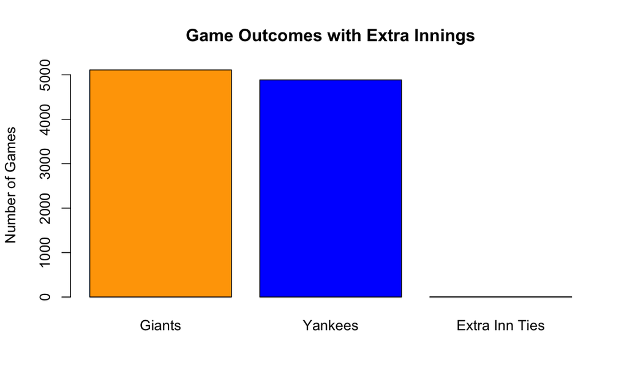

```r
win_counts <- c(teamA_wins, teamB_wins, extra_inning_ties)
barplot(win_counts,
        names.arg=c("Giants", "Yankees", "Extra Inn Ties"),
        col=c("orange", "blue", "purple"),
        main="Game Outcomes with Extra Innings",
        ylab="Number of Games")
```

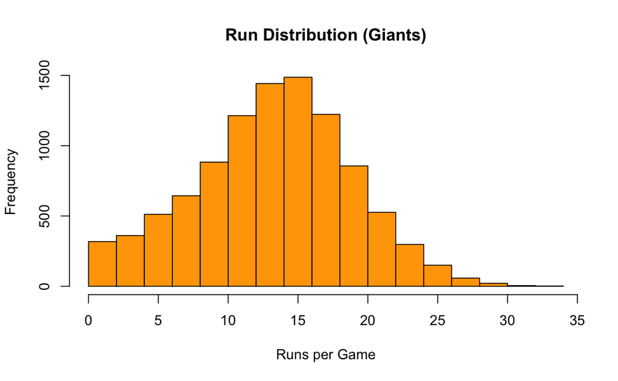

```r
# Convert to numeric if necessary
game_results_df$RunsA <- as.numeric(game_results_df$RunsA)
game_results_df$RunsB <- as.numeric(game_results_df$RunsB)

# Histogram for Team A (Giants)
hist(game_results_df$RunsA,
     col = "orange",
     main = "Run Distribution (Giants)",
     xlab = "Runs per Game",
     breaks = 20)
```

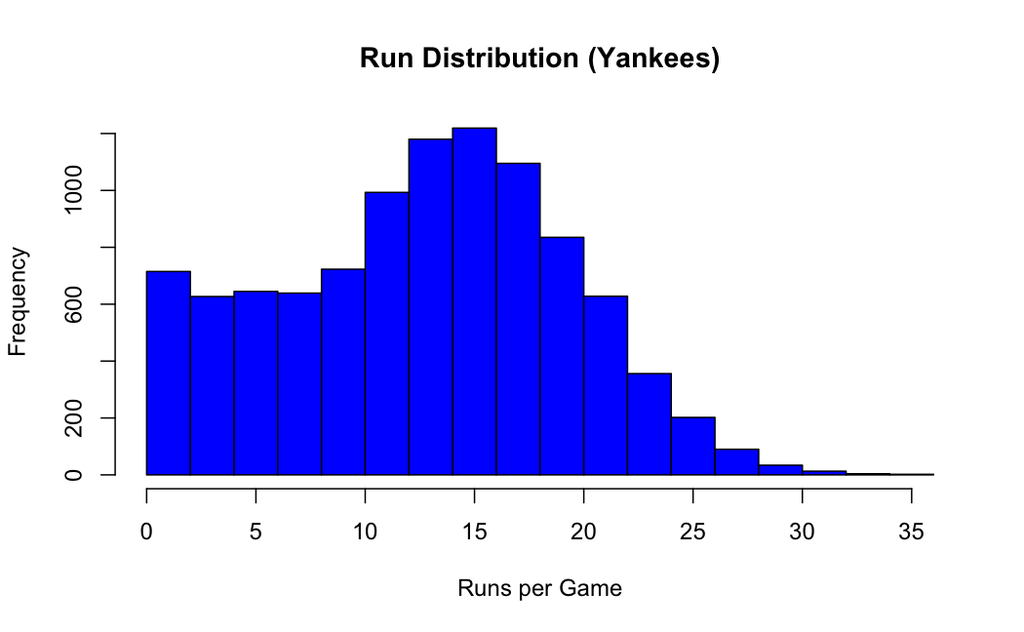

```r
# Histogram for Team B (Yankees)
hist(game_results_df$RunsB,
     col = "blue",
     main = "Run Distribution (Yankees)",
     xlab = "Runs per Game",
     breaks = 20)
```

```r
# Parameters
start <- 1
seed_num <- 200

# Store Runs and Games Separately for Each Team
total_runs_A <- numeric(seed_num + 1)
total_games_A <- numeric(seed_num + 1)
total_runs_B <- numeric(seed_num + 1)
total_games_B <- numeric(seed_num + 1)

# Simulation loop for Team A & Team B
for (seed in 1:seed_num) {
  set.seed(seed)  # Ensure reproducibility

  game_result <- simulate_game(final_teamA_matrix, final_teamB_matrix, n_innings=7)

  # Extract values correctly
  total_runs_A[seed + 1] <- total_runs_A[seed] + game_result$RunsA
  total_games_A[seed + 1] <- total_games_A[seed] + game_result$InningsPlayed

  total_runs_B[seed + 1] <- total_runs_B[seed] + game_result$RunsB
  total_games_B[seed + 1] <- total_games_B[seed] + game_result$InningsPlayed
}

# Calculate average runs per inning safely
average_per_seed_A <- ifelse(total_games_A > 0, total_runs_A / total_games_A, 0)
average_per_seed_B <- ifelse(total_games_B > 0, total_runs_B / total_games_B, 0)

# Create a line plot comparing both teams
plot(1:seed_num, average_per_seed_A[-1], type = "l", col = "orange",
     xlab = "Number of Games", ylab = "Average Runs per Inning",
     main = "Average Runs per Inning (Giants vs. Yankees)")
lines(1:seed_num, average_per_seed_B[-1], col = "blue")
```

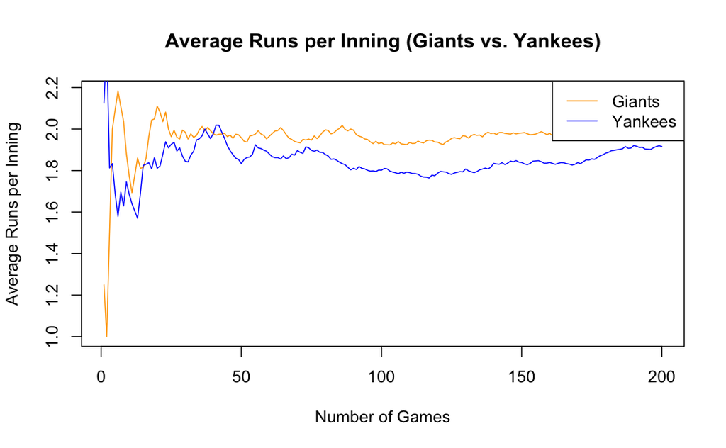

```r
# Add legend
legend("topright", legend = c("Giants", "Yankees"), col = c("orange", "blue"), lty = 1)
```

```r
# Convert list-columns to numeric vectors
game_results_df$RunsA <- unlist(game_results_df$RunsA)
game_results_df$RunsB <- unlist(game_results_df$RunsB)

# 1. Average runs per game
mean_runs_teamA <- mean(game_results_df$RunsA)
mean_runs_teamB <- mean(game_results_df$RunsB)

# 2. Shutout percentages
shutout_teamA <- sum(game_results_df$RunsA == 0) / nrow(game_results_df)
shutout_teamB <- sum(game_results_df$RunsB == 0) / nrow(game_results_df)

# Display results
cat("Average Runs Scored by Giants:", mean_runs_teamA, "\n")
```

```
Average Runs Scored by Giants: 13.6791
```

```r
cat("Average Runs Scored by Yankees:", mean_runs_teamB, "\n")
```

```
Average Runs Scored by Yankees: 13.0853
```

```r
cat("Percentage of Shutouts (Giants held scoreless):", shutout_teamA * 100, "%\n")
```

```
Percentage of Shutouts (Giants held scoreless): 1.19 %
```

```r
cat("Percentage of Shutouts (Yankees held scoreless):", shutout_teamB * 100, "%\n")
```

```
Percentage of Shutouts (Yankees held scoreless): 2.85 %
```

```r
# Convert 'Result' and 'InningsPlayed' from lists to character/numeric since we used lists
game_results_df$Result <- sapply(game_results_df$Result, as.character)
game_results_df$InningsPlayed <- sapply(game_results_df$InningsPlayed, as.numeric)

# Standard deviation of runs scored
sd_teamA <- sd(game_results_df$RunsA, na.rm = TRUE)
sd_teamB <- sd(game_results_df$RunsB, na.rm = TRUE)

# Close wins (winning by exactly 1 run)
close_wins_A <- sum((game_results_df$RunsA - game_results_df$RunsB == 1) &
                     (game_results_df$Result == "Team A Wins"), na.rm = TRUE)

close_wins_B <- sum((game_results_df$RunsB - game_results_df$RunsA == 1) &
                     (game_results_df$Result == "Team B Wins"), na.rm = TRUE)

# Big wins (winning by more than 5 runs)
big_wins_A <- sum(game_results_df$RunsA - game_results_df$RunsB > 5, na.rm = TRUE)
big_wins_B <- sum(game_results_df$RunsB - game_results_df$RunsA > 5, na.rm = TRUE)

# Display results
cat("Standard deviation of Giants's runs:", sd_teamA, "\n")
```

```
Standard deviation of Giants's runs: 5.653983
```

```r
cat("Standard deviation of Yankees's runs:", sd_teamB, "\n")
```

```
Standard deviation of Yankees's runs: 6.654371
```

```r
cat("Giants Close Wins:", close_wins_A, "\nYankees Close Wins:", close_wins_B, "\n")
```

```
Giants Close Wins: 450
Yankees Close Wins: 444
```

```r
cat("Giants Big Wins:", big_wins_A, "\nYankees Big Wins:", big_wins_B, "\n")
```

```
Giants Big Wins: 3145
Yankees Big Wins: 2740
```